# HW4MSIA401

Qiaozhen Wu, Qiana Yang, Dian Yu, Yijun Wu

10/18/2020

## 4.10

```r
library(car)
library(dplyr)
data <- c(8,1,1,1,
          8,1,1,0,
          8,1,1,0,
          0,0,9,1,
          0,0,9,1,
          0,0,9,1,
          2,7,0,1,
          2,7,0,1,
          2,7,0,1,
          0,0,0,10,
          0,0,0,10,
          0,0,0,10)
webster <- data.frame(cbind(matrix(data, nrow = 12, ncol = 4, byrow = TRUE), rep(10, 12)))
colnames(webster) <- c("x1", "x2","x3", "x4", "y")
```

### (a)

```r
cor(webster[, -5])
```

```
##             x1          x2         x3         x4
## x1  1.00000000  0.05230658 -0.3433818 -0.4976109
## x2  0.05230658  1.00000000 -0.4315953 -0.3706964
## x3 -0.34338179 -0.43159531  1.0000000 -0.3551214
## x4 -0.49761095 -0.37069641 -0.3551214  1.0000000
```

### No correlation coefficent exceed 0.5 in absolute value. Therefore, correlations do no indicate multilinearity.

### (b)

```r
fit <- lm(y ~., data = webster)
vif(fit)
```

```
##       x1       x2       x3       x4
## 178.2874 158.0460 257.9074 289.3750
```

### All vif exceed 150 and the greatest is 289.375. Therefore, vifs indicate multilinearity.

## 4.11

### (a)

```r
mpg<- read.csv(here::here("mpg.csv"))
cor(mpg)
```

```
##                     mpg  cylinders displacement horsepower     weight
## mpg           1.0000000 -0.7776175   -0.8051269 -0.7784268 -0.8322442
## cylinders    -0.7776175  1.0000000    0.9508233  0.8429834  0.8975273
## displacement -0.8051269  0.9508233    1.0000000  0.8972570  0.9329944
## horsepower   -0.7784268  0.8429834    0.8972570  1.0000000  0.8645377
## weight       -0.8322442  0.8975273    0.9329944  0.8645377  1.0000000
## acceleration  0.4233285 -0.5046834   -0.5438005 -0.6891955 -0.4168392
##              acceleration
## mpg             0.4233285
## cylinders      -0.5046834
## displacement   -0.5438005
## horsepower     -0.6891955
## weight         -0.4168392
## acceleration    1.0000000
```

### Yes there is multicollinearity since there are values like 0.95 and 0.8 which are all over 0.7.

###(b)

```r
fit_5 <- lm(mpg ~ cylinders+displacement+horsepower+weight + acceleration , data = mpg)
summary (fit_5)
```

```
##
## Call:
## lm(formula = mpg ~ cylinders + displacement + horsepower + weight +
##     acceleration, data = mpg)
##
## Residuals:
##      Min       1Q   Median       3Q      Max
## -11.5816  -2.8618  -0.3404   2.2438  16.3416
##
## Coefficients:
##                Estimate Std. Error t value Pr(>|t|)
## (Intercept)   4.626e+01  2.669e+00  17.331   <2e-16 ***
## cylinders    -3.979e-01  4.105e-01  -0.969   0.3330
## displacement -8.313e-05  9.072e-03  -0.009   0.9927
## horsepower   -4.526e-02  1.666e-02  -2.716   0.0069 **
## weight       -5.187e-03  8.167e-04  -6.351    6e-10 ***
## acceleration -2.910e-02  1.258e-01  -0.231   0.8171
## ---
## Signif. codes:  0 '***' 0.001 '**' 0.01 '*' 0.05 '.' 0.1 ' ' 1
##
## Residual standard error: 4.247 on 386 degrees of freedom
## Multiple R-squared:  0.7077, Adjusted R-squared:  0.7039
## F-statistic: 186.9 on 5 and 386 DF,  p-value: < 2.2e-16
```

### Multicollinearity is reflected in the fact that three of the variables - cylinders, displacement and acceleration- all appears to be insignificant– overall F statistic is significant, but 3 out of 5 of the t values are nonsignificant.

### (c)

```r
fit_4 <- lm(mpg ~ cylinders+horsepower+weight + acceleration , data = mpg)
summary (fit_4)
```

```
##
## Call:
## lm(formula = mpg ~ cylinders + horsepower + weight + acceleration,
##     data = mpg)
##
## Residuals:
##      Min       1Q   Median       3Q      Max
## -11.5807  -2.8628  -0.3409   2.2427  16.3422
##
## Coefficients:
##                Estimate Std. Error t value Pr(>|t|)
## (Intercept)  46.2739915  2.4481591  18.902  < 2e-16 ***
## cylinders    -0.4004602  0.3032615  -1.321  0.18744
## horsepower   -0.0452970  0.0160604  -2.820  0.00504 **
## weight       -0.0051902  0.0007341  -7.070 7.26e-12 ***
## acceleration -0.0289828  0.1248944  -0.232  0.81661
## ---
## Signif. codes:  0 '***' 0.001 '**' 0.01 '*' 0.05 '.' 0.1 ' ' 1
##
## Residual standard error: 4.242 on 387 degrees of freedom
## Multiple R-squared:  0.7077, Adjusted R-squared:  0.7047
## F-statistic: 234.2 on 4 and 387 DF,  p-value: < 2.2e-16
```

### It decreases the value of cylinders and makes it more significant. And the change increased ajusted r squated slightly

### (d)

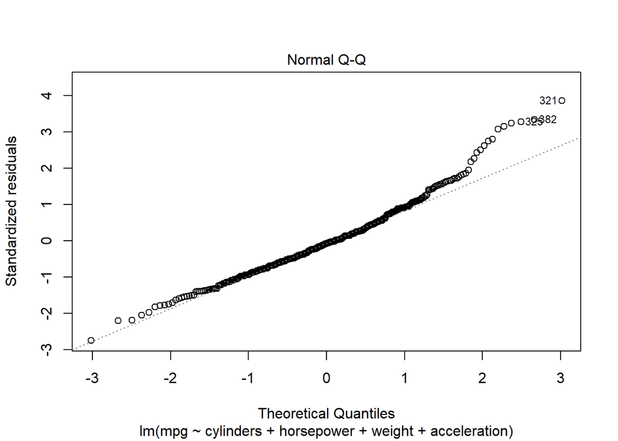

```r
plot(fit_4,2)
```

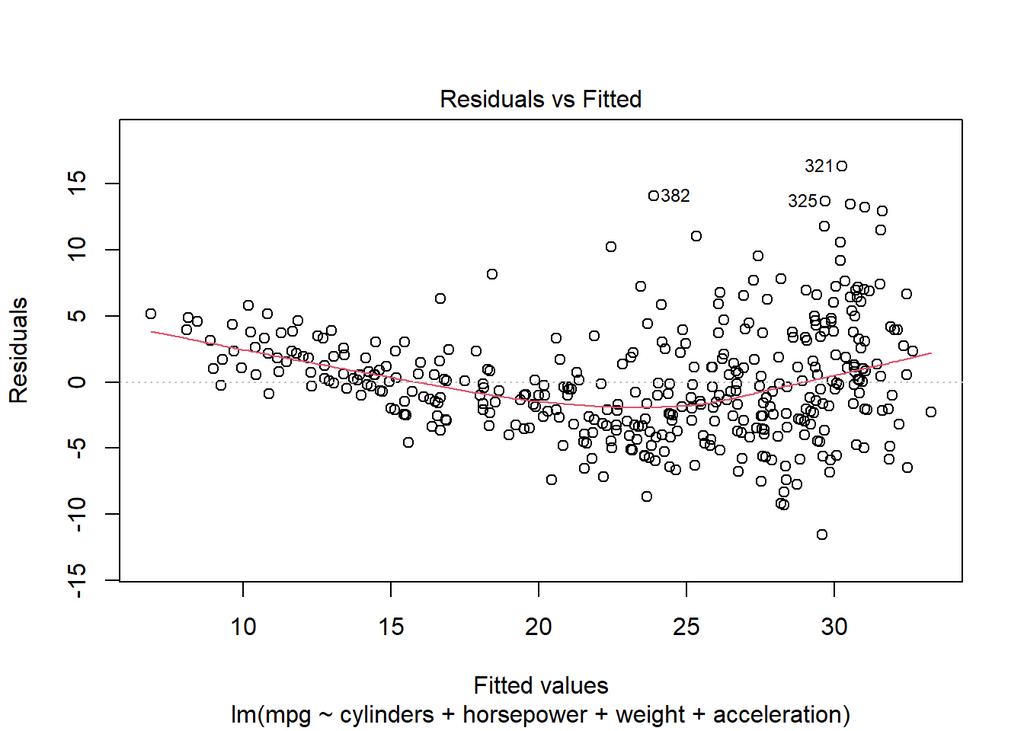

```r
plot(fit_4,1)
```

```r
vif (fit_4)
```

```
##    cylinders   horsepower       weight acceleration
##     5.815763     8.305342     8.449468     2.580303
```

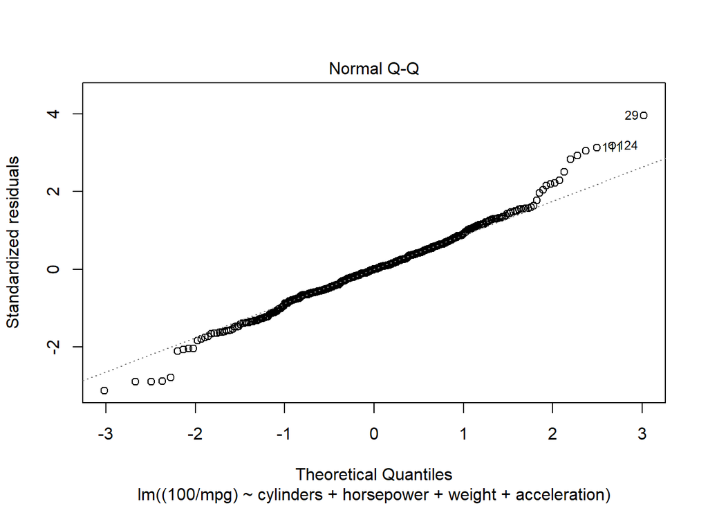

```r
fit_inverse <- lm((100/mpg) ~ cylinders+horsepower+weight + acceleration , data = mpg)
plot(fit_inverse,2)
```

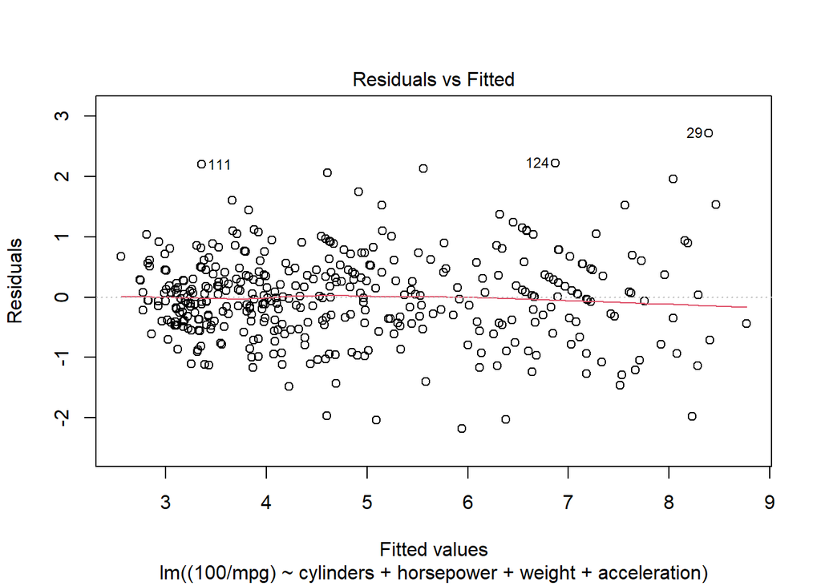

```r
plot(fit_inverse,1)
```

```r
vif(fit_inverse)
```

```
##    cylinders   horsepower       weight acceleration
##     5.815763     8.305342     8.449468     2.580303
```

### Yes the transformation removed the flaws of the previous model. Variability of the residuals is more consistent. VIF does not change, and that’s because we are only doing transformation on the y’s (and hence the correlation between the x’s still remains the same).

###(e)

```r
100/predict(fit_inverse, newdata = data.frame(cylinders = 6, horsepower= 105, weight = 3000, acceleration = 15), interval = "predict")
```

```
##        fit    lwr      upr
## 1 20.59855 28.903 16.00109
```

## 4.12

###(a)

```r
library (tidyverse)
```

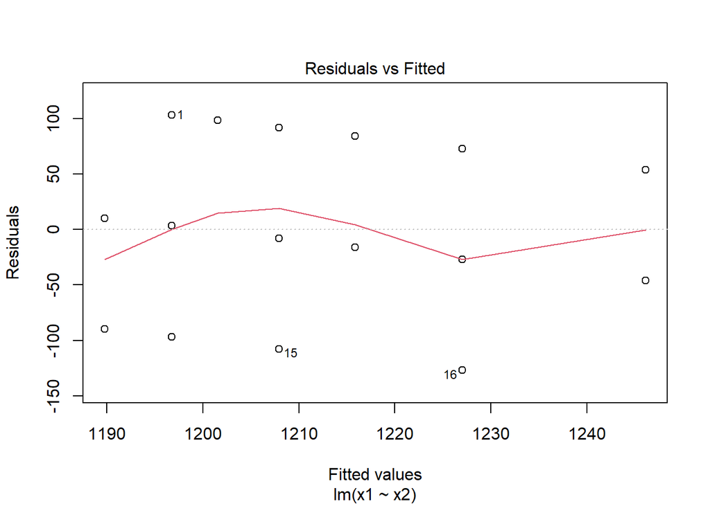

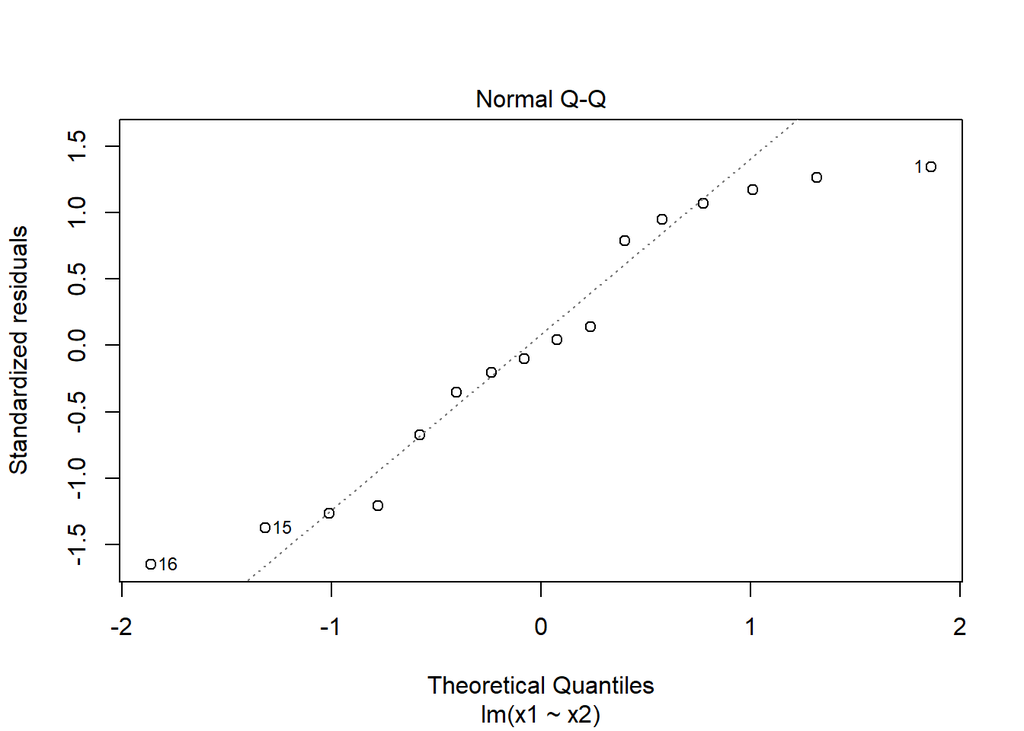

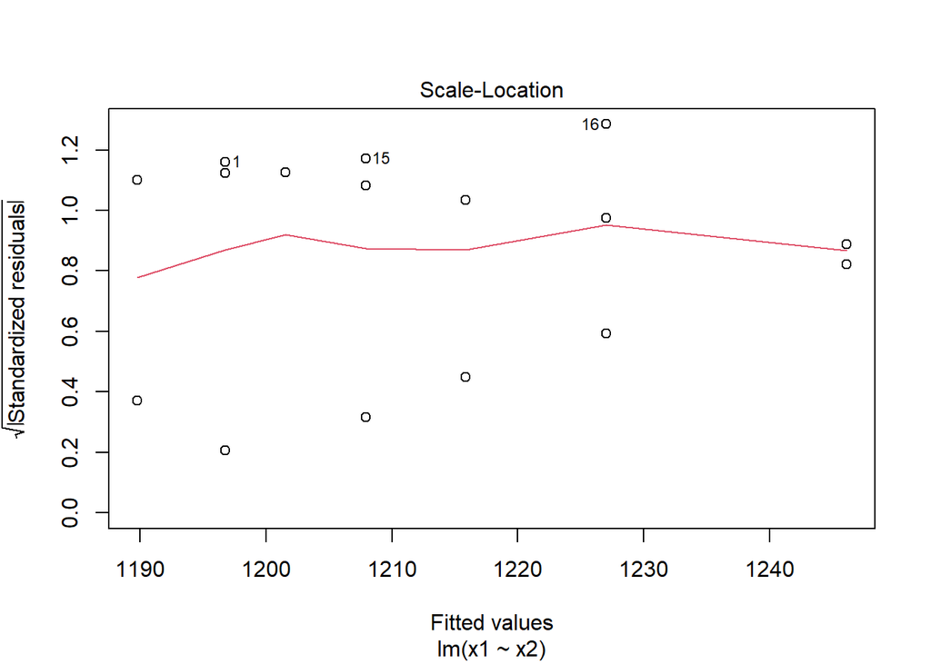

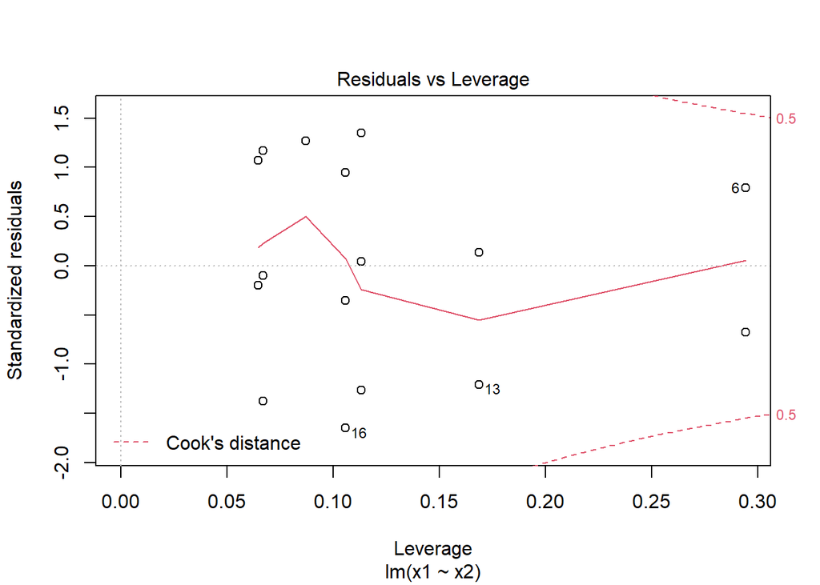

```r
acetylene <-
  tribble(~x1,  ~x2,   ~x3,   ~y,
           1300, 7.5,  0.0120, 49.0,
           1300, 9,    0.0120, 50.2,
           1300, 11,   0.0115, 50.5,
           1300, 13.5, 0.0130, 48.5,
           1300, 17,   0.0135, 47.5,
           1300, 23,   0.0120, 44.5,
           1200, 5.3,  0.0400, 28.0,
           1200, 7.5,  0.0380, 31.5,
           1200, 11,   0.0320, 34.5,
           1200, 13.5, 0.0260, 35.0,
           1200, 17,   0.0340, 38.0,
           1200, 23,   0.0410, 38.5,
           1100, 5.3,  0.0840, 15.0,
           1100, 7.5,  0.0980, 17.0,
           1100, 11,   0.0920, 20.5,
           1100, 17,   0.0860, 29.5
           )

fitx1x2 <- lm (x1 ~ x2, data = acetylene)
fixx2x3 <- lm (x2 ~x3, data = acetylene)
fixx1x3 <- lm (x1~x3, data = acetylene)
plot(fitx1x2)
```

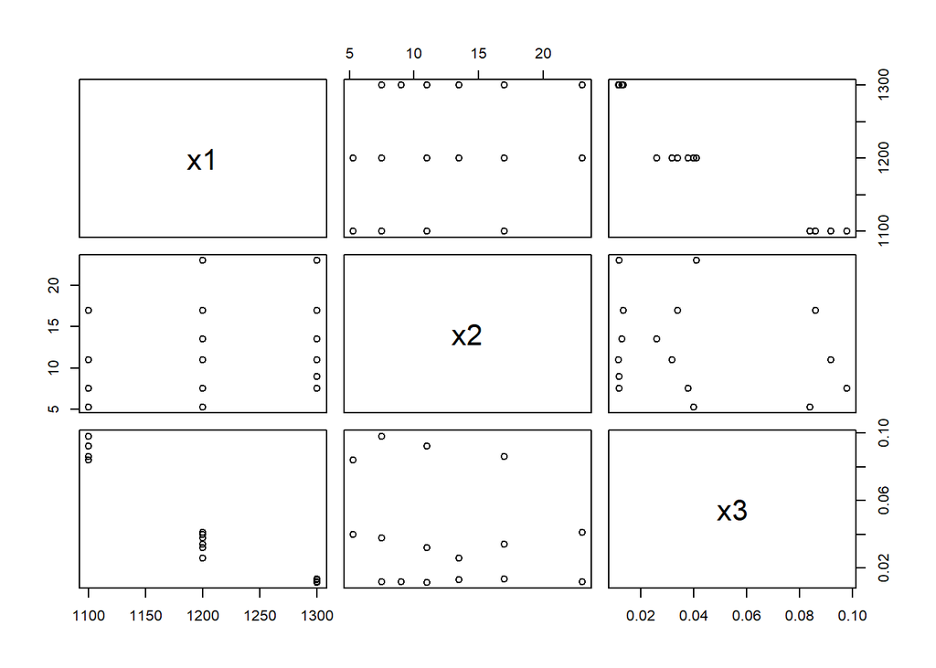

```r
plot(acetylene[1:3])
```

### Yes x1 and x3 appears to be highly correlated.

###(b)

```r
cor(acetylene)
```

```
##            x1         x2         x3          y
## x1  1.0000000  0.2236278 -0.9582041  0.9450377
## x2  0.2236278  1.0000000 -0.2402310  0.3700350
## x3 -0.9582041 -0.2402310  1.0000000 -0.9139777
## y   0.9450377  0.3700350 -0.9139777  1.0000000
```

```r
sumtable <-summary(acetylene)
sumtable
```

```
##        x1             x2              x3                y
##  Min.   :1100   Min.   : 5.30   Min.   :0.01150   Min.   :15.00
##  1st Qu.:1175   1st Qu.: 7.50   1st Qu.:0.01275   1st Qu.:29.12
##  Median :1200   Median :11.00   Median :0.03300   Median :36.50
##  Mean   :1212   Mean   :12.44   Mean   :0.04031   Mean   :36.11
##  3rd Qu.:1300   3rd Qu.:17.00   3rd Qu.:0.05175   3rd Qu.:47.75
##  Max.   :1300   Max.   :23.00   Max.   :0.09800   Max.   :50.50
```

```r
#12.1 Yes I saw that the correlation between x1 and x3 is around 0.9 which is higher than 0.7,so there is multicollinearity.
acetylene
```

```
## # A tibble: 16 x 4
##       x1    x2     x3     y
##    <dbl> <dbl>  <dbl> <dbl>
##  1  1300   7.5 0.012   49
##  2  1300   9   0.012   50.2
##  3  1300  11   0.0115  50.5
##  4  1300  13.5 0.013   48.5
##  5  1300  17   0.0135  47.5
##  6  1300  23   0.012   44.5
##  7  1200   5.3 0.04    28
##  8  1200   7.5 0.038   31.5
##  9  1200  11   0.032   34.5
## 10  1200  13.5 0.026   35
## 11  1200  17   0.034   38
## 12  1200  23   0.041   38.5
## 13  1100   5.3 0.084   15
## 14  1100   7.5 0.098   17
## 15  1100  11   0.092   20.5
## 16  1100  17   0.086   29.5
```

```r
fixmodel_old<- lm (y~ x1+x2+x3+x1*x2+x1*x3+x2*x3+I(x1^2)+ I(x2^2) + I(x3^2),acetylene)
vif(fixmodel_old)
```

```
##           x1           x2           x3      I(x1^2)      I(x2^2)      I(x3^2)
## 2.856749e+06 1.095614e+04 2.017163e+06 2.501945e+06 6.573359e+01 1.266710e+04
##        x1:x2        x1:x3        x2:x3
## 9.802903e+03 1.428092e+06 2.403594e+02
```

### All of the VIFs are extremely high, signifying strong multicollinearity.

### (c)

```r
library("car")
acetylene["x1"] <- acetylene["x1"] - mean(acetylene$x1)
acetylene["x2"]  <-acetylene["x2"] - mean(acetylene$x2)
acetylene["x3"] <- acetylene["x3"] - mean(acetylene$x3)
fixmodel_new <- lm (y~ x1+x2+x3+x1*x2+x1*x3+x2*x3+I(x1^2)+ I(x2^2) + I(x3^2), acetylene )
vif(fixmodel_new)
```

```
##          x1          x2          x3     I(x1^2)     I(x2^2)     I(x3^2)
##  375.247759    1.740631  680.280039 1762.575365    3.164318 1156.766284
##       x1:x2       x1:x3       x2:x3
##   31.037059 6563.345193   35.611286
```

### Yes the transformation has decreased the vif value, but the VIFs are still very high.